# NKI Studie

### Grupp 3

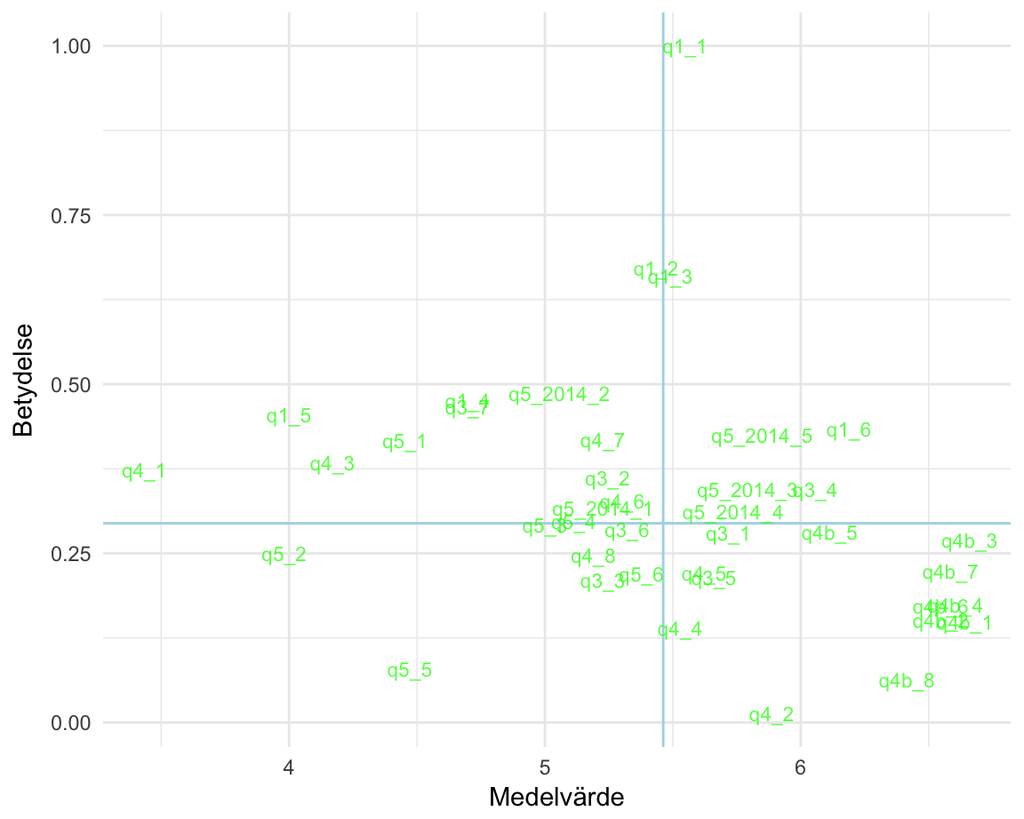

## Drivkraftsanalyser

### Drivkraftsanalys, en kort beskrivning

Ju högre upp på y-axeln en variabel ligger desto större betydelse (påverkan) har denna på total kundnöjdhet. Ju längre till höger på x-axeln vi finner variablen desto mer nöjd är man med denna faktor/egenskap på den 7-gradiga skalan. De viktigaste förbättringsområdena finner vi längst upp till vänster i diagrammet där faktorer finns som relativt sett får ett lägre betyg (medelvärde) men har en högst betydelse för kundnöjdhet.

q1_1 Totalt sett är jag är mycket nöjd med företaget som leverantör q1_2 Jag rekommenderar gärna företaget till andra q1_3 Om jag skulle välja leverantör inom området idag skulle jag välja företaget igen q1_4 Företaget erbjuder prisvärda produkter och tjänster q1_5 Företaget är ett innovativt företag q1_6 Företaget är ett tryggt och stabilt företag q3_1 är kunniga och kompetenta  
q3_2 är tillräckligt lätta att få tag på q3_3 är kundorienterade, dvs förstår våra synpunkter och behov q3_4 är vänliga och tillmötesgående q3_5 har hög branschkunskap q3_6 löser alltid våra problem till hög belåtenhet q3_7 ger mig tydlig återkoppling q4_1 är enkelt att komma igång med för nya medarbetare q4_2 har hög driftsäkerhet q4_3 har funktioner som är enkla och lätta att använda q4_4 har snabb responstid/prestanda q4_5 erbjuder innehåll jag inte kan få hos någon annan leverantör idag q4_6 möter mina behov vad det gäller innehåll i lösningen q4_7 motsvarar mina förväntningar q4_8 har sällan systemfel q4b_1 är enkelt att komma igång med för nya medarbetare q4b_2 har hög driftsäkerhet q4b_3 har funktioner som är enkla och lätta att använda q4b_4 har snabb responstid/prestanda q4b_5 erbjuder innehåll jag inte kan få hos någon annan leverantör idag q4b_6 möter mina behov vad det gäller innehåll i lösningen q4b_7 motsvarar mina förväntningar q4b_8 har sällan systemfel q5_1 Har användarmanualer som är lätta att förstå q5_2 Har en bra kundwebb (kräver login) för min informationsinhämtning q5_3 Har nyhetsbrev som är informativa q5_4 Ger mig den information jag behöver vad gäller nyheter/ändringar i mitt system q5_5 Har en hemsida där jag lätt hittar den info jag behöver q5_6 Ger löpande information om vad som händer på företaget q5_2014_1 Smarta affärslösningar q5_2014_2 Skapar en bättre vardag för dig q5_2014_3 Ansvarstagande personal q5_2014_4 Engagerad personal q5_2014_5 Serviceinriktad personal

# Resultat enskilda frågor

### Plot 1

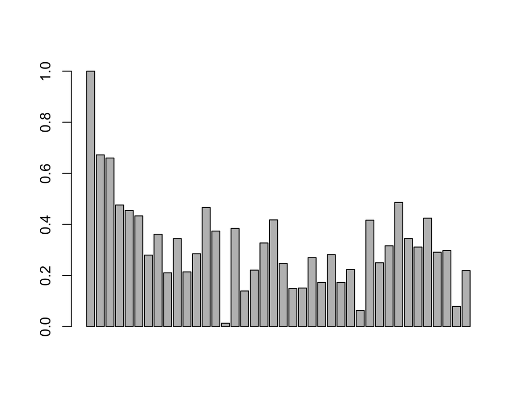

### Plot2

[figure not shown]

# Nyckeltal

[interactive chart not shown]

[interactive chart not shown]

[interactive chart not shown]

## Rows

55

71

36

### Diagram

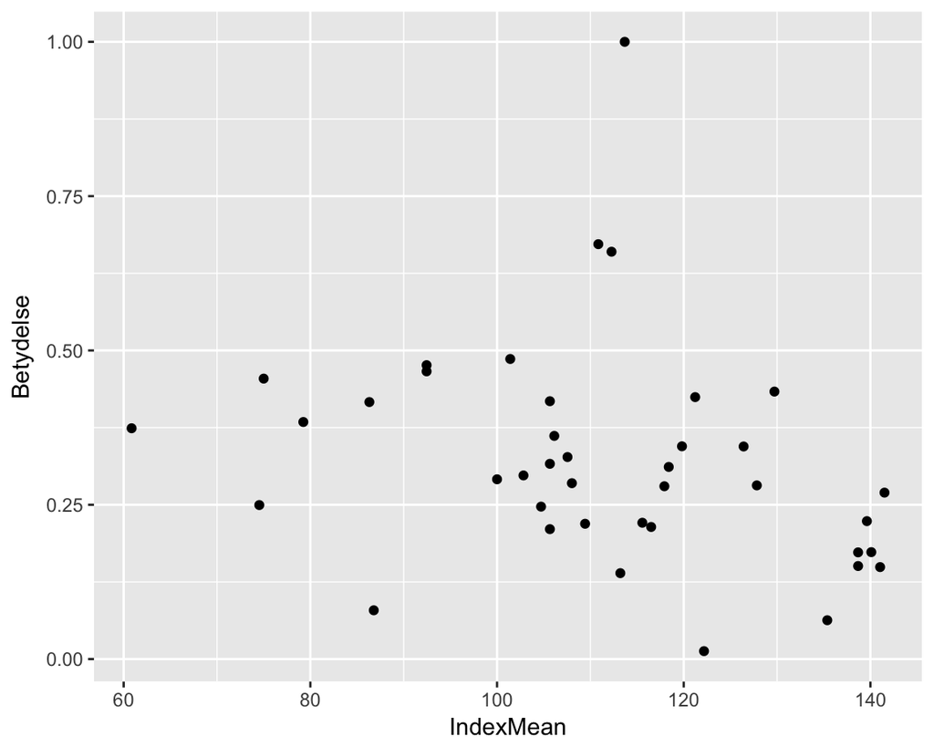

# Tabell

### Signifikanstest tabell

[output not shown]

[output cut: 13 more lines]

# Plats

[interactive chart not shown]

# Appendix